# Vegetation Manhours — Unit-Pricing Pipeline (CatBoost)

| Phase | What happens | Data used |
| --- | --- | --- |
| 1–5 | Load, clean, engineer, feeder-grouped splits, base matrices | all (no fitting) |
| 6 | Baseline vs. road challenger (shared params) | fit Train+Val, score Test |
| 7 | Full-feature splits (road + alley + land cover + 4 area candidates) saved | Train-fit transforms |
| 8–9 | Dev harness; choose the Urban/Suburban/Rural source column | CV on Train+Val |
| 10 | Feature pruning **per model unit** | CV |
| 11 | Loss/hyperparameter tuning per unit (unit-specific loss families; conditional quantile) | CV |
| 12 | Tier schemes: hour cuts (searched) and volume quartiles (Train) | CV / Train |
| 13 | **Sample-weighted** tuning on under-performing tiers, per scheme | CV |
| 14 | Multi-quantile models (P10 / P50 / P90) | CV |
| 15 | CV comparison → champion + primary tier scheme | CV |
| 16 | Test confirmation + **24-class risk tables** + investigate list | Test |
| 17 | Decisions / artifacts | — |
| 18 | **Holdout breakpoint** → 24-class risk tables on holdout | Holdout (once) |

**v3 changes:** tier cluster features removed · over/under-sampling replaced by tier sample weights · hour tiers ⇄ volume tiers comparison · per-unit loss families (accessible; inaccessible × suburban / rural / urban) · 24-class accessibility × area × tier risk tables on Test and Holdout.

## 0. Configuration

```python
import os
import sys

import numpy as np
import pandas as pd

current_dir = "/mnt/projects/VEG_Contractors/2026unitization/2026unitization/notebooks"
# Get the parent directory of the current file
parent_dir = os.path.abspath(os.path.join(current_dir, os.pardir))
# Construct the path to the 'src/modeling' folder
modeling_dir = os.path.join(parent_dir, "src", "modeling")
# Add 'src/modeling' to the system path
sys.path.insert(0, modeling_dir)
import veg_pipeline_updated as vp  # noqa: E402

READY_FOR_FINAL_HOLDOUT = False          # <-- BREAKPOINT: True only for the one-time final sign-off run
RUN_MODE = os.environ.get("VEG_RUN_MODE", "full")   # "full" | "fast" (smoke test)
SHOW_PLOTS = True                        # figures are also saved to FIG_DIR

INPUT_DIR = os.environ.get("VEG_INPUT_DIR", "../input_data")
OUTPUT_DIR = os.environ.get("VEG_OUTPUT_DIR", "./deployment")
SPLIT_DIR = os.path.join(OUTPUT_DIR, "splits")
FULL_SPLIT_DIR = os.path.join(SPLIT_DIR, "full_features")
FIG_DIR = os.path.join(OUTPUT_DIR, "figures")
FORCE_RESPLIT = False
RUN_EDA = True

# Re-tune switches: True | False | "auto" (auto = re-tune only if features / families / cuts changed)
TUNE_ROAD = False #"auto"
TUNE_REGRESSION = True #"auto"
TUNE_WEIGHTED = True #"auto"

# --- Model units: who gets which loss families -------------------------------------------------
# Accessible: MAE / Huber / Tweedie.  Inaccessible-Suburban: Huber / Tweedie / Q0.55 / Q0.60.
# Inaccessible-Rural (and Urban, unspecified -> same as rural): MAE / Huber / Tweedie, and quantile
# 0.55 / 0.60 ONLY if CV still shows under-prediction after tuning.
MODEL_UNITS = vp.default_model_units()
# TEST confusion grids show Inaccessible-Heavy recall stuck at 7-10% across
# every current candidate (vs 37-46% for Accessible-Heavy), with 66-74% of
# true-Heavy Inaccessible spans landing exactly one tier low. The existing
# 0.55/0.60 quantile ceiling isn't reaching far enough into the tail -
# widen it for Inaccessible units specifically.
MODEL_UNITS = vp.with_conditional_quantiles(MODEL_UNITS, "Inaccessible", (0.55, 0.60, 0.65, 0.70, 0.75))


# --- Tier schemes ------------------------------------------------------------------------------
TIER_SCHEMES_TO_TUNE = ["hours", "volume"]   # weighted tuning is run for each listed scheme
PRIMARY_TIER_SCHEME = "auto"                 # "hours" | "volume" | "auto" (higher 24-class eta2 on CV)
VOLUME_BIN_SCOPE = "global"                  # quartiles over all Train spans, or "segment" (per regime)
USE_RECOMMENDED_HOUR_CUTS = False
HOUR_CUTS_OVERRIDE = {"Accessible": [2.25 , 3.75, 5], "Inaccessible": [3.5 ,5.5, 7.5]}                    # TODO(veg-team): {"Accessible": [...3], "Inaccessible": [...3]}
CHAMPION_OVERRIDE = None                     # e.g. "Weighted (volume tiers)"
AREA_COLUMN_OVERRIDE = "area_lcxfm" # e.g. "area_lcxfm"; None = auto-select by CV Selection_Score

# --- 24-class risk table ------------------------------------------------------------------------
vp.RISK_WEIGHTS.update({"width": 0.30, "cv": 0.25, "mae": 0.25, "under_bias": 0.20})
vp.INVESTIGATE_CFG.update({"quantile": 0.75, "min_flags": 2, "risk_threshold": 1.25, "min_n": 30})

BASELINE_PARAMS = {"iterations": 1200, "depth": 6, "learning_rate": 0.05, "l2_leaf_reg": 5.0,
                   "loss_function": "MAE", "eval_metric": "MAE", **vp.CB_FIXED}
DEV_CFG = vp.default_dev_cfg(RUN_MODE)
for d in (OUTPUT_DIR, SPLIT_DIR, FIG_DIR):
    os.makedirs(d, exist_ok=True)
np.random.seed(vp.RANDOM_STATE)


def fig(name):
    return os.path.join(FIG_DIR, name)


print(f"RUN_MODE={RUN_MODE} | READY_FOR_FINAL_HOLDOUT={READY_FOR_FINAL_HOLDOUT}")
vp.show(pd.Series(DEV_CFG), "Dev config")
```

```
RUN_MODE=full | READY_FOR_FINAL_HOLDOUT=False

Dev config
```

```
n_folds                                      5
es_feeder_share                           0.15
early_stopping_rounds                      100
max_iterations                            3000
n_trials_road                               35
n_trials_reg                                40
n_trials_weighted                           25
min_unit_spans                            1500
underpred_ratio_tol                       0.03
underpred_rate_tol                        0.55
multi_quantile_alphas          [0.1, 0.5, 0.9]
report_test_for_experiments               True
w_span_mae                                 0.5
w_feeder_wape                              0.5
show_progress                             True
dtype: object
```

## 1–3. Load, clean, engineer

```python
df = vp.load_span_data(INPUT_DIR)
df = vp.join_span_aggregates(df, INPUT_DIR)
df = vp.merge_accessibility(df, INPUT_DIR)
df, feature_cols = vp.build_model_frame(df)
feature_cols = [c for c in feature_cols if c not in vp.LEGACY_TIER_FEATURE_COLS]

if RUN_EDA:
    vp.show(df.groupby("inaccessible")[vp.TARGET].describe(), "Manhours by accessibility")
    if "veg_tier" in df.columns:
        vp.show(vp.segment_summary(df[df["veg_tier"].notna()]), "Accessibility x veg_tier (analysis only)")
```

```
Duplicate bay records found: 36
Spans: 24,284 | unique completion days: 134
Mean manhours by accessibility:
 inaccessible
0    3.154935
1    5.493508
Name: manhours, dtype: float64
Non-veg spans removed: 881
Candidate features: 59 | spans: 23,400

Manhours by accessibility
```

| inaccessible | count | mean | std | min | 25% | 50% | 75% | max |
| --- | --- | --- | --- | --- | --- | --- | --- | --- |
| 0 | 12988.0 | 3.1978 | 2.5288 | 0.0 | 2.0 | 2.0 | 4.0 | 48.0 |
| 1 | 10412.0 | 5.5393 | 4.1914 | 0.0 | 2.0 | 4.0 | 8.0 | 36.0 |

```
Accessibility x veg_tier (analysis only)
```

|  | inaccessible | veg_tier | count | mean | median | p10 | p90 | mean_ci_lower | mean_ci_upper |
| --- | --- | --- | --- | --- | --- | --- | --- | --- | --- |
| 0 | 0 | Heavy | 2433 | 5.4451 | 4.0 | 2.0 | 9.0 | 5.2884 | 5.5884 |
| 1 | 0 | Light | 4067 | 1.9267 | 2.0 | 1.0 | 3.0 | 1.8913 | 1.9578 |
| 2 | 0 | Medium | 6404 | 3.1606 | 3.0 | 2.0 | 5.0 | 3.1152 | 3.2084 |
| 3 | 1 | Heavy | 3512 | 7.7363 | 7.5 | 2.0 | 14.0 | 7.5709 | 7.9043 |
| 4 | 1 | Light | 1613 | 3.0982 | 2.0 | 1.0 | 6.0 | 3.0063 | 3.2041 |
| 5 | 1 | Medium | 5261 | 4.8317 | 4.0 | 1.5 | 9.0 | 4.7402 | 4.9215 |

```python
DEVICE_MAP = vp.load_protective_device_map(os.path.join(INPUT_DIR, "span_data.pkl"))
```

```
NOTE: 9,103 bays map to more than one distinct 'protective_device' value - each collapsed to a single deterministic value to prevent double-counting in aggregation.
NOTE: 9,101 bays map to more than one distinct 'major_protective_device' value - each collapsed to a single deterministic value to prevent double-counting in aggregation.
Loaded protective-device map for 241,344 bays (protective_device, major_protective_device).
```

## 4. Feeder-grouped splits

Saved splits are reused unless `FORCE_RESPLIT`. Legacy cluster-tier columns are dropped if present.

```python
if not FORCE_RESPLIT and vp.splits_available(SPLIT_DIR):
    splits = vp.load_splits(SPLIT_DIR)
else:
    splits = vp.make_feeder_splits(df, feature_cols)
    vp.save_splits(splits, SPLIT_DIR)
splits = vp.drop_legacy_tier_features(splits)
vp.show(vp.split_summary(splits), "Split summary")

df = df.set_index("bay_unique", drop=False)
df.index.name = "bay_unique"
for s in vp.SPLIT_NAMES:
    for part in ("X", "y", "meta"):
        splits[s][part].index = splits[s][part].index.astype(df.index.dtype)
```

```
Loaded saved splits from ./deployment/splits

Split summary
```

| split | spans | share | feeders | missing_dates | min_date | max_date |
| --- | --- | --- | --- | --- | --- | --- |
| train | 12337 | 0.5284 | 249 | 953 | 2024-06-04 | 2026-07-24 |
| test | 4159 | 0.1781 | 54 | 640 | 2026-01-22 | 2026-07-09 |
| valid | 2182 | 0.0935 | 54 | 222 | 2026-01-20 | 2026-07-09 |
| holdout | 4671 | 0.2001 | 73 | 0 | 2026-04-01 | 2026-06-24 |

## 5. Base matrices + accessibility routing

```python
X_red = {s: splits[s]["X"].fillna(0).copy() for s in vp.SPLIT_NAMES}
y_split = {s: vp.align_target(splits[s]["y"], X_red[s], f"y_{s}") for s in vp.SPLIT_NAMES}
access_lookup = vp.build_accessibility_lookup(splits)
flags_all = pd.concat([vp.get_accessibility_flags(access_lookup, X_red[s].index) for s in vp.SPLIT_NAMES])
print({s: X_red[s].shape for s in vp.SPLIT_NAMES})
```

```
{'train': (12337, 59), 'test': (4159, 59), 'valid': (2182, 59), 'holdout': (4671, 59)}
```

## 6. Baseline vs. road challenger (shared parameters)

```python
X_tune_base = pd.concat([X_red["train"], X_red["valid"]])
y_tune = pd.concat([y_split["train"], y_split["valid"]]).reindex(X_tune_base.index)
baseline_cols = X_tune_base.columns.tolist()
baseline_models = vp.fit_accessibility_pair(X_tune_base, y_tune, flags_all, BASELINE_PARAMS, label="Baseline - ")

road_csv = vp.resolve_road_feature_csv([os.path.join(INPUT_DIR, "Accessibility", "bay_geometry_df.csv")])
road_by_bay, road_numeric, road_categorical = vp.load_road_features(road_csv)
bay_key = vp.clean_bay_key(df["bay"])
road_frames = {s: vp.lookup_road_features(X_red[s], bay_key, road_by_bay) for s in vp.SPLIT_NAMES}
road_tf = vp.fit_road_transforms(road_frames["train"], road_numeric, road_categorical)   # Train only
road_frames = {s: vp.apply_road_transforms(f, road_tf) for s, f in road_frames.items()}
road_cols = road_tf["numeric_cols"] + road_categorical

X_road = {s: vp.build_road_matrix(X_red[s], road_frames[s], df, road_cols) for s in vp.SPLIT_NAMES}
road_columns = X_road["train"].columns.tolist()
X_road = {s: X_road[s].reindex(columns=road_columns) for s in vp.SPLIT_NAMES}
X_tune_road = pd.concat([X_road["train"], X_road["valid"]])

ROAD_PARAMS_PATH = os.path.join(OUTPUT_DIR, "road_catboost_params.json")
saved_road = vp.read_json(ROAD_PARAMS_PATH) if os.path.exists(ROAD_PARAMS_PATH) else {}
if TUNE_ROAD is True or (TUNE_ROAD == "auto" and saved_road.get("feature_columns") != road_columns):
    print("Tuning shared road params (feature list changed)...")
    road_params, _ = vp.tune_shared_road_params(
        X_tune_road, y_tune, df.loc[X_tune_road.index, "feeder"], road_categorical, DEV_CFG["n_trials_road"],
        n_folds=DEV_CFG["n_folds"], max_iter_range=(100, 300) if RUN_MODE == "fast" else (500, 1800),
        show_progress=DEV_CFG["show_progress"])
    vp.write_json({"params": road_params, "feature_columns": road_columns,
                   "categorical_features": road_categorical}, ROAD_PARAMS_PATH)
else:
    road_params = saved_road["params"]
    print(f"Loaded shared road params from {ROAD_PARAMS_PATH}")
road_params = {**road_params, "loss_function": "MAE", "eval_metric": "MAE", **vp.CB_FIXED}
road_models = vp.fit_accessibility_pair(X_tune_road, y_tune, flags_all, road_params,
                                        cat_features=road_categorical, label="Road challenger - ")

base_test = vp.predict_accessibility_pair(baseline_models, X_red["test"][baseline_cols], flags_all)
road_test = vp.predict_accessibility_pair(road_models, X_road["test"], flags_all)
vp.show(pd.DataFrame([vp.calculate_metrics("Baseline (no road)", y_split["test"], base_test),
                      vp.calculate_metrics("Road challenger", y_split["test"], road_test)]),
        "Section 6 TEST comparison (shared params)")
```

```
Baseline - Accessible: fit on 7,837 spans
Baseline - Inaccessible: fit on 6,682 spans
Road features available: 66 numeric, 8 categorical
Loaded shared road params from ./deployment/road_catboost_params.json
Road challenger - Accessible: fit on 7,837 spans
Road challenger - Inaccessible: fit on 6,682 spans

Section 6 TEST comparison (shared params)
```

|  | Model | Count | MAE | Median_AE | RMSE | R2 | Bias | P90_AE | Underprediction_Rate |
| --- | --- | --- | --- | --- | --- | --- | --- | --- | --- |
| 0 | Baseline (no road) | 4159 | 2.1713 | 1.3299 | 3.5966 | 0.2114 | -0.8022 | 5.1055 | 0.5090 |
| 1 | Road challenger | 4159 | 2.1465 | 1.2295 | 3.6830 | 0.1730 | -1.1090 | 5.0566 | 0.5573 |

## 7. Full-feature splits (all four splits saved)

```python
missing_area = [c for c in vp.AREA_CANDIDATE_COLS if c not in road_columns]
if missing_area:
    raise KeyError(f"Area candidates missing from road join: {missing_area}")

FULL_X = {s: X_road[s] for s in ["train", "valid", "test", "holdout"]}
FULL_Y = {s: y_split[s] for s in FULL_X}
FULL_META = {s: vp.build_meta(FULL_X[s], df, flags_all) for s in FULL_X}
for s in FULL_X:
    for c in road_categorical:
        FULL_X[s][c] = FULL_X[s][c].astype(str)
vp.assert_no_leaky_columns(road_columns)

FEATURE_GROUPS = vp.build_feature_groups(road_columns, road_cols)
vp.show(pd.Series({k: len(v) for k, v in FEATURE_GROUPS.items()}, name="n"), "Feature groups")
vp.show(pd.concat({c: FULL_META["train"][f"area_class__{c}"].value_counts(normalize=True)
                   for c in vp.AREA_CANDIDATE_COLS}, axis=1).fillna(0),
        "Area-class share on TRAIN (Unmapped -> fill vp.AREA_VALUE_MAP)")
if vp.VOLUME_COL not in road_columns:
    raise KeyError(f"{vp.VOLUME_COL} is required for volume tiers.")

vp.save_full_splits(FULL_X, FULL_Y, FULL_META, FULL_SPLIT_DIR, {
    "feature_columns": road_columns, "categorical_columns": road_categorical,
    "feature_groups": FEATURE_GROUPS, "area_value_map": vp.AREA_VALUE_MAP,
    "road_numeric_imputation": road_tf["medians"].to_dict(),
})
```

```
Feature groups
```

```
base_span                 60
road_core                 60
alley                      6
land_cover_numeric         5
land_cover_categorical     1
area_candidates            4
Name: n, dtype: int64
```

```
Area-class share on TRAIN (Unmapped -> fill vp.AREA_VALUE_MAP)
```

|  | dominant_land_cover_general | area_lc | area_lcxfm | area_xfmr |
| --- | --- | --- | --- | --- |
| Suburban | 0.6576 | 0.6724 | 0.7286 | 0.6643 |
| Urban | 0.2544 | 0.2975 | 0.1632 | 0.2392 |
| Rural | 0.0880 | 0.0302 | 0.1081 | 0.0965 |

```
Saved full-feature splits (136 features) to ./deployment/splits/full_features
```

## 8. Development harness

All decisions below use feeder-grouped CV on Train+Validation. Early stopping uses a feeder slice of each training fold (unweighted); Test is confirmation only.

```python
ctx = vp.DevContext(FULL_X, FULL_Y, FULL_META, road_categorical, DEV_CFG)
for k, f in enumerate(ctx.folds):
    print(f"Fold {k}: fit={len(f['fit']):,} es={len(f['es']):,} eval={len(f['eval']):,}")

REF_PARAMS = {k: v for k, v in road_params.items() if k not in vp.CB_FIXED and k != "eval_metric"}
REF_PARAMS["iterations"] = DEV_CFG["max_iterations"]
REF_PARAMS["loss_function"] = "RMSE"
if RUN_MODE == "fast":
    REF_PARAMS["learning_rate"] = max(REF_PARAMS.get("learning_rate", 0.05), 0.1)
PROVISIONAL_HOUR_CUTS = {k: list(v) for k, v in vp.PROVISIONAL_TIER_CUTS.items()}
```

```
Fold 0: fit=10,514 es=1,101 eval=2,904
Fold 1: fit=9,002 es=2,613 eval=2,904
Fold 2: fit=9,969 es=1,646 eval=2,904
Fold 3: fit=9,420 es=2,195 eval=2,904
Fold 4: fit=10,038 es=1,578 eval=2,903
```

## 9. Urban / Suburban / Rural source column

```python
# AREA COLUMN =============================================================
# Lighter, faster settings just for area-candidate ranking -- we only need
# the RELATIVE ordering of Selection_Score across candidates, not a
# production-fidelity fit. Uses the same params as REF_PARAMS but caps
# iterations and early stopping much lower.
AREA_SEARCH_PARAMS = {**REF_PARAMS, "iterations": 600}
AREA_SEARCH_CFG_OVERRIDES = {"early_stopping_rounds": 40}
_old_es = ctx.cfg.get("early_stopping_rounds")
ctx.cfg["early_stopping_rounds"] = AREA_SEARCH_CFG_OVERRIDES["early_stopping_rounds"]
ctx.cfg["report_test_for_experiments"] = False

_, area_cv_table, area_test_table = vp.select_area_column(ctx, AREA_SEARCH_PARAMS, PROVISIONAL_HOUR_CUTS)

ctx.cfg["early_stopping_rounds"] = _old_es   # restore for everything downstream

CHOSEN_AREA_COL, AUTO_CHOSEN_AREA_COL, AREA_OVERRIDE_USED = vp.resolve_area_column(
    area_cv_table, override=AREA_COLUMN_OVERRIDE)
AREA_CLASS_COL = f"area_class__{CHOSEN_AREA_COL}"
DROPPED_AREA_COLS = [c for c in vp.AREA_CANDIDATE_COLS if c != CHOSEN_AREA_COL]

vp.show(area_cv_table[vp.COMPARE_COLS + ["Selection_Score"]].sort_values("Selection_Score"), "Area candidates - CV")
if AREA_OVERRIDE_USED:
    print(f"AREA_COLUMN_OVERRIDE active: using {CHOSEN_AREA_COL!r} "
          f"(CV auto-selection would have chosen {AUTO_CHOSEN_AREA_COL!r}).")
if area_cv_table.loc[CHOSEN_AREA_COL, "Selection_Score"] > area_cv_table.loc["none", "Selection_Score"]:
    print(f"NOTE: {CHOSEN_AREA_COL} does not beat 'none' on CV; kept because pricing needs the area dimension.")
FEATURES_AFTER_AREA = [c for c in ctx.X_dev.columns if c not in DROPPED_AREA_COLS]

ctx.area_class_col = AREA_CLASS_COL
print(f"Chosen area column: {CHOSEN_AREA_COL} | Unmapped share: {(ctx.meta_dev[AREA_CLASS_COL] == 'Unmapped').mean():.1%}")
print("\nModel units:")
UNITS = vp.resolve_units(ctx, MODEL_UNITS)
UNIT_NAMES = [u.name for u in UNITS]
vp.show(pd.crosstab(ctx.meta_dev["inaccessible"], ctx.meta_dev[AREA_CLASS_COL]), "Dev spans: inaccessible x area")

# Get a real Test-confirmed number for the WINNER only (1 candidate, not 4).
if CHOSEN_AREA_COL != "none":
    winner_feats = [c for c in ctx.X_dev.columns if c not in DROPPED_AREA_COLS]
    winner_spec = {}
    for u in UNITS:
        cv_result = vp.cv_unit(ctx, u, winner_feats, REF_PARAMS)
        winner_spec[u.name] = {
            "features": winner_feats,
            "params": REF_PARAMS,
            "iterations": vp.iterations_for_refit(ctx, cv_result["best_iteration"], ("train", "valid")),
        }
    winner_pred, _, _ = vp.refit_and_predict(ctx, winner_spec, UNITS)
    area_test_table = pd.DataFrame(
        [vp.evaluate_combined(CHOSEN_AREA_COL, ctx.full_y["test"], winner_pred, ctx.full_meta["test"], PROVISIONAL_HOUR_CUTS)]
    ).set_index("Model")
    vp.show(area_test_table[vp.COMPARE_COLS], "Area candidate (winner) - TEST (confirmation only)")
```

```
  none                         CV MAE=2.0883 feeder R2=0.8878 feeder WAPE=0.2280
  dominant_land_cover_general  CV MAE=2.0832 feeder R2=0.8900 feeder WAPE=0.2253
  area_lc                      CV MAE=2.0843 feeder R2=0.8898 feeder WAPE=0.2264
  area_lcxfm                   CV MAE=2.0826 feeder R2=0.8877 feeder WAPE=0.2269
  area_xfmr                    CV MAE=2.0863 feeder R2=0.8884 feeder WAPE=0.2281

Area candidates - CV
```

| Model | Accessible_MAE | Inaccessible_MAE | Combined_MAE | Combined_R2 | Combined_Bias | Feeder_R2 | Feeder_WAPE | Feeder_MdAPE | Feeder_Within_15pct | Feeder_Within_20pct | Feeder_Total_Bias_Pct | Accessible_TierAcc | Accessible_TierQWK | Inaccessible_TierAcc | Inaccessible_TierQWK | Selection_Score |
| --- | --- | --- | --- | --- | --- | --- | --- | --- | --- | --- | --- | --- | --- | --- | --- | --- |
| dominant_land_cover_general | 1.3825 | 2.9051 | 2.0832 | 0.2466 | 0.0462 | 0.8900 | 0.2253 | 0.2197 | 0.3531 | 0.4752 | 0.0110 | 0.2012 | 0.3776 | 0.2620 | 0.2744 | 0.9929 |
| area_lc | 1.3791 | 2.9114 | 2.0843 | 0.2474 | 0.0449 | 0.8898 | 0.2264 | 0.2190 | 0.3564 | 0.4686 | 0.0107 | 0.2001 | 0.3791 | 0.2519 | 0.2676 | 0.9957 |
| area_lcxfm | 1.3727 | 2.9151 | 2.0826 | 0.2464 | 0.0492 | 0.8877 | 0.2269 | 0.2117 | 0.3564 | 0.4620 | 0.0117 | 0.2026 | 0.3790 | 0.2576 | 0.2720 | 0.9963 |
| area_xfmr | 1.3793 | 2.9154 | 2.0863 | 0.2453 | 0.0534 | 0.8884 | 0.2281 | 0.2137 | 0.3597 | 0.4686 | 0.0127 | 0.1992 | 0.3765 | 0.2531 | 0.2687 | 0.9999 |
| none | 1.3796 | 2.9196 | 2.0883 | 0.2444 | 0.0471 | 0.8878 | 0.2280 | 0.2163 | 0.3564 | 0.4587 | 0.0112 | 0.1996 | 0.3781 | 0.2514 | 0.2549 | 1.0000 |

```
AREA_COLUMN_OVERRIDE active: using 'area_lcxfm' (CV auto-selection would have chosen 'dominant_land_cover_general').
Chosen area column: area_lcxfm | Unmapped share: 0.0%

Model units:
  unit Accessible               dev rows= 7,837 train_scope=unit     families=['MAE', 'Huber', 'Tweedie']
  unit Inaccessible-Suburban    dev rows= 5,674 train_scope=unit     families=['Huber', 'Tweedie', 'Q0.55', 'Q0.60'] conditional quantiles=[0.55, 0.6, 0.65, 0.7, 0.75]
  unit Inaccessible-Rural       dev rows=   460 train_scope=segment  families=['MAE', 'Huber', 'Tweedie'] conditional quantiles=[0.55, 0.6, 0.65, 0.7, 0.75]
  unit Inaccessible-Urban       dev rows=   548 train_scope=segment  families=['MAE', 'Huber', 'Tweedie'] conditional quantiles=[0.55, 0.6, 0.65, 0.7, 0.75]

Dev spans: inaccessible x area
```

| area_class__area_lcxfm inaccessible | Rural | Suburban | Urban |
| --- | --- | --- | --- |
| 0 | 1058 | 4903 | 1876 |
| 1 | 460 | 5674 | 548 |

```
Area candidate (winner) - TEST (confirmation only)
```

| Model | Accessible_MAE | Inaccessible_MAE | Combined_MAE | Combined_R2 | Combined_Bias | Feeder_R2 | Feeder_WAPE | Feeder_MdAPE | Feeder_Within_15pct | Feeder_Within_20pct | Feeder_Total_Bias_Pct | Accessible_TierAcc | Accessible_TierQWK | Inaccessible_TierAcc | Inaccessible_TierQWK |
| --- | --- | --- | --- | --- | --- | --- | --- | --- | --- | --- | --- | --- | --- | --- | --- |
| area_lcxfm | 1.655 | 2.7892 | 2.187 | 0.2393 | -0.4245 | 0.9748 | 0.1475 | 0.2566 | 0.3889 | 0.4444 | -0.0889 | 0.2147 | 0.3948 | 0.3198 | 0.3429 |

## 10. Feature pruning per model unit

Group ablations (incl. alley), near-duplicates and out-of-fold importance drops; the 1-SE rule keeps the smallest good set. Only the chosen area column is protected (the cluster tier features no longer exist).

```
Accessible pruning (constants dropped: ['inaccessible', 'nearest_road_missing', 'nearest_road_attribute_missing', 'nearest_road_aadt_missing', 'span_zero_length', 'road_zero_length', 'road_feature_source_match', 'road_feature_source_missing'])
```

| Experiment | n_features | CV_MAE | CV_MAE_SE | CV_Feeder_WAPE | best_iteration | Delta_MAE_vs_all | Chosen |
| --- | --- | --- | --- | --- | --- | --- | --- |
| -bottom_35pct | 82 | 1.3533 | 0.0545 | 0.1962 | 254 | -0.0167 | False |
| -bottom_20pct | 101 | 1.3547 | 0.0556 | 0.1959 | 224 | -0.0152 | False |
| -bottom_50pct | 63 | 1.3551 | 0.0546 | 0.1970 | 210 | -0.0149 | True |
| -nonpositive_importance | 80 | 1.3574 | 0.0571 | 0.1969 | 213 | -0.0126 | False |
| -alley | 119 | 1.3577 | 0.0515 | 0.1978 | 239 | -0.0123 | False |
| -road_all(incl alley) | 66 | 1.3603 | 0.0557 | 0.2003 | 440 | -0.0097 | False |
| -road_core | 72 | 1.3689 | 0.0419 | 0.2012 | 271 | -0.0011 | False |
| all | 125 | 1.3700 | 0.0422 | 0.2013 | 258 | 0.0000 | False |
| -corr_duplicates | 114 | 1.3724 | 0.0453 | 0.2017 | 257 | 0.0024 | False |
| -land_cover | 119 | 1.3734 | 0.0448 | 0.2007 | 235 | 0.0035 | False |

```
-> Accessible: '-bottom_50pct' (63 features); alley ablation delta MAE -0.0123 (negative = alley hurt)

Inaccessible-Suburban pruning (constants dropped: ['inaccessible', 'nearest_road_missing', 'nearest_road_attribute_missing', 'nearest_road_aadt_missing', 'span_zero_length', 'road_zero_length', 'road_feature_source_match', 'road_feature_source_missing', 'area_lcxfm'])
```

| Experiment | n_features | CV_MAE | CV_MAE_SE | CV_Feeder_WAPE | best_iteration | Delta_MAE_vs_all | Chosen |
| --- | --- | --- | --- | --- | --- | --- | --- |
| -bottom_35pct | 82 | 2.9695 | 0.1564 | 0.2845 | 505 | -0.0483 | False |
| -bottom_50pct | 63 | 2.9727 | 0.1481 | 0.2833 | 512 | -0.0452 | True |
| -nonpositive_importance | 65 | 2.9758 | 0.1499 | 0.2849 | 385 | -0.0420 | False |
| -bottom_20pct | 101 | 2.9761 | 0.1545 | 0.2824 | 729 | -0.0418 | False |
| -alley | 119 | 2.9975 | 0.1644 | 0.2867 | 403 | -0.0204 | False |
| -corr_duplicates | 115 | 3.0165 | 0.1655 | 0.2919 | 909 | -0.0013 | False |
| all | 125 | 3.0178 | 0.1658 | 0.2929 | 827 | 0.0000 | False |
| -land_cover | 119 | 3.0193 | 0.1669 | 0.2916 | 932 | 0.0015 | False |
| -road_all(incl alley) | 66 | 3.0274 | 0.1519 | 0.2961 | 427 | 0.0096 | False |
| -road_core | 72 | 3.0527 | 0.1702 | 0.3046 | 894 | 0.0348 | False |

```
-> Inaccessible-Suburban: '-bottom_50pct' (63 features); alley ablation delta MAE -0.0204 (negative = alley hurt)

Inaccessible-Rural pruning (constants dropped: ['inaccessible', 'nearest_road_missing', 'nearest_road_attribute_missing', 'nearest_road_aadt_missing', 'span_zero_length', 'road_zero_length', 'road_feature_source_match', 'road_feature_source_missing'])
```

| Experiment | n_features | CV_MAE | CV_MAE_SE | CV_Feeder_WAPE | best_iteration | Delta_MAE_vs_all | Chosen |
| --- | --- | --- | --- | --- | --- | --- | --- |
| -corr_duplicates | 116 | 3.3607 | 0.1788 | 0.3543 | 118 | -0.0316 | False |
| -alley | 119 | 3.3671 | 0.1858 | 0.3543 | 87 | -0.0252 | False |
| -bottom_35pct | 82 | 3.3746 | 0.2047 | 0.3486 | 74 | -0.0177 | False |
| -land_cover | 119 | 3.3811 | 0.1903 | 0.3601 | 72 | -0.0112 | False |
| all | 125 | 3.3923 | 0.2002 | 0.3599 | 73 | 0.0000 | False |
| -nonpositive_importance | 73 | 3.4041 | 0.2015 | 0.3535 | 91 | 0.0118 | False |
| -bottom_20pct | 101 | 3.4221 | 0.2007 | 0.3565 | 66 | 0.0298 | False |
| -bottom_50pct | 63 | 3.4487 | 0.2085 | 0.3547 | 66 | 0.0564 | True |
| -road_core | 72 | 3.5134 | 0.1971 | 0.3771 | 72 | 0.1211 | False |
| -road_all(incl alley) | 66 | 3.5455 | 0.1873 | 0.3874 | 54 | 0.1532 | False |

```
-> Inaccessible-Rural: '-bottom_50pct' (63 features); alley ablation delta MAE -0.0252 (negative = alley hurt)

Inaccessible-Urban pruning (constants dropped: ['inaccessible', 'nearest_road_missing', 'nearest_road_attribute_missing', 'nearest_road_aadt_missing', 'span_zero_length', 'road_zero_length', 'road_feature_source_match', 'road_feature_source_missing'])
```

| Experiment | n_features | CV_MAE | CV_MAE_SE | CV_Feeder_WAPE | best_iteration | Delta_MAE_vs_all | Chosen |
| --- | --- | --- | --- | --- | --- | --- | --- |
| -bottom_35pct | 82 | 2.2152 | 0.1205 | 0.3453 | 406 | -0.0456 | False |
| -bottom_50pct | 63 | 2.2175 | 0.1239 | 0.3449 | 430 | -0.0433 | True |
| -nonpositive_importance | 92 | 2.2402 | 0.1141 | 0.3460 | 401 | -0.0206 | False |
| -corr_duplicates | 116 | 2.2427 | 0.1320 | 0.3550 | 365 | -0.0182 | False |
| -bottom_20pct | 101 | 2.2569 | 0.1153 | 0.3482 | 356 | -0.0039 | False |
| all | 125 | 2.2608 | 0.1354 | 0.3594 | 328 | 0.0000 | False |
| -land_cover | 119 | 2.2710 | 0.1358 | 0.3617 | 311 | 0.0102 | False |
| -road_all(incl alley) | 66 | 2.2811 | 0.1548 | 0.3646 | 458 | 0.0202 | False |
| -road_core | 72 | 2.2888 | 0.1450 | 0.3494 | 351 | 0.0280 | False |
| -alley | 119 | 2.2933 | 0.1484 | 0.3682 | 309 | 0.0325 | False |

```
-> Inaccessible-Urban: '-bottom_50pct' (63 features); alley ablation delta MAE +0.0325 (negative = alley hurt)
```

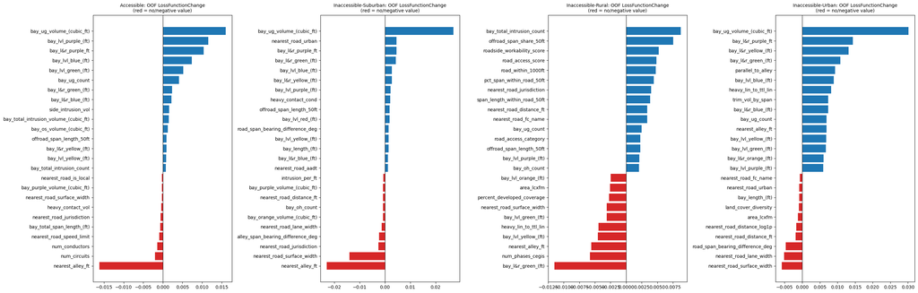

```python
PROTECTED = [CHOSEN_AREA_COL]
prune = {}
for u in UNITS:
    prune[u.name] = vp.prune_unit_features(ctx, u, FEATURES_AFTER_AREA, REF_PARAMS, PROTECTED, FEATURE_GROUPS)
    t = prune[u.name]["table"]
    vp.show(t.sort_values("CV_MAE"), f"{u.name} pruning (constants dropped: {prune[u.name]['constants']})")
    print(f"-> {u.name}: '{prune[u.name]['chosen']}' ({len(prune[u.name]['selected'])} features); "
          f"alley ablation delta MAE {t.loc['-alley', 'Delta_MAE_vs_all']:+.4f} (negative = alley hurt)")
SELECTED_FEATURES = {n: prune[n]["selected"] for n in UNIT_NAMES}
PRUNE_REF = {n: prune[n]["cv"][prune[n]["chosen"]] for n in UNIT_NAMES}
vp.plot_importance({n: prune[n]["importance"] for n in UNIT_NAMES}, fig("10_oof_importance.png"), SHOW_PLOTS)
```

## 11. Loss + hyperparameter tuning per unit

```python
REG_PATH = os.path.join(OUTPUT_DIR, "unit_regression_params.json")
expected_reg = {u.name: {"features": SELECTED_FEATURES[u.name], "families": u.families,
                         "train_scope": u.train_scope} for u in UNITS}
REG_SPEC = {}
if TUNE_REGRESSION is True or (TUNE_REGRESSION == "auto" and not vp.spec_is_current(REG_PATH, expected_reg)):
    for u in UNITS:
        feats = SELECTED_FEATURES[u.name]
        ref = PRUNE_REF[u.name]
        objective_fn = vp.make_objective_fn(ctx, {"mae": ref["mae"], "feeder_wape": ref["feeder_wape"]})
        print(f"\nTuning {u.name} over {u.families} ({DEV_CFG['n_trials_reg']} trials)")
        study = vp.run_study(f"reg_{u.name}", vp.make_study_objective(ctx, u, feats, u.families, objective_fn),
                             DEV_CFG["n_trials_reg"], vp.default_seed_params(REF_PARAMS, u.families[0]),
                             show_progress=DEV_CFG["show_progress"])
        spec = {**expected_reg[u.name], "trial_params": study.best_trial.params, "loss_override": None,
                "best_family": study.best_trial.params["loss_family"], "families_used": list(u.families),
                "cv_objective": study.best_value, "quantile_check": None}
        study.trials_dataframe().to_csv(os.path.join(OUTPUT_DIR, f"unit_regression_trials_{u.name}.csv"), index=False)

        if u.conditional_quantiles:
            params = vp.params_from_trial(spec["trial_params"], u.families, DEV_CFG["max_iterations"])
            base = vp.cv_unit(ctx, u, feats, params)
            check = {"sum_ratio": base["sum_ratio"], "under_rate": base["under_rate"],
                     "underpredicting": vp.underprediction_flag(base, DEV_CFG), "tried": {}}
            if check["underpredicting"]:
                for alpha in u.conditional_quantiles:
                    q_params = {**params, "loss_function": vp.loss_label_to_catboost(vp.quantile_label(alpha))}
                    rq = vp.cv_unit(ctx, u, feats, q_params)
                    check["tried"][alpha] = {"objective": objective_fn(rq["oof"].index, rq["oof"].to_numpy()),
                                             "sum_ratio": rq["sum_ratio"], "under_rate": rq["under_rate"]}
                best_alpha = min(check["tried"], key=lambda a: check["tried"][a]["objective"])
                if check["tried"][best_alpha]["objective"] < spec["cv_objective"]:
                    label = vp.quantile_label(best_alpha)
                    spec.update(loss_override=vp.loss_label_to_catboost(label), best_family=label,
                                families_used=list(u.families) + [label],
                                cv_objective=check["tried"][best_alpha]["objective"])
            spec["quantile_check"] = check
            print(f"  quantile check: {check}")
        REG_SPEC[u.name] = spec
    vp.write_json(REG_SPEC, REG_PATH)
else:
    REG_SPEC = vp.read_json(REG_PATH)
    print(f"Loaded unit regression specs from {REG_PATH}")

reg_cv = {}
for u in UNITS:
    s = REG_SPEC[u.name]
    s["params"] = vp.params_from_trial(s["trial_params"], s["families"], DEV_CFG["max_iterations"], s["loss_override"])
    reg_cv[u.name] = vp.cv_unit(ctx, u, s["features"], s["params"])
    s["cv_best_iteration"] = reg_cv[u.name]["best_iteration"]
REG_OOF = vp.combine_predictions({n: r["oof"] for n, r in reg_cv.items()}, ctx.X_dev.index)
vp.show(pd.DataFrame({n: {"loss": REG_SPEC[n]["params"]["loss_function"], "cv_mae": reg_cv[n]["mae"],
                          "pruned_ref_mae": PRUNE_REF[n]["mae"], "feeder_wape": reg_cv[n]["feeder_wape"],
                          "sum_ratio": reg_cv[n]["sum_ratio"], "under_rate": reg_cv[n]["under_rate"],
                          "quantile_check": (REG_SPEC[n]["quantile_check"] or {}).get("underpredicting")}
                      for n in UNIT_NAMES}).T, "Tuned unit models (CV)")
```

```
Tuning Accessible over ['MAE', 'Huber', 'Tweedie'] (40 trials)
```

```
Tuning Inaccessible-Suburban over ['Huber', 'Tweedie', 'Q0.55', 'Q0.60'] (40 trials)
```

```
  quantile check: {'sum_ratio': 0.9771755900526681, 'under_rate': 0.43179414874867816, 'underpredicting': False, 'tried': {}}

Tuning Inaccessible-Rural over ['MAE', 'Huber', 'Tweedie'] (40 trials)
```

```
  quantile check: {'sum_ratio': 0.838481778428161, 'under_rate': 0.46304347826086956, 'underpredicting': True, 'tried': {0.55: {'objective': 0.9812254583502587, 'sum_ratio': 0.79708623417478, 'under_rate': 0.4260869565217391}, 0.6: {'objective': 0.9623604210675218, 'sum_ratio': 1.0568677542631368, '…

Tuning Inaccessible-Urban over ['MAE', 'Huber', 'Tweedie'] (40 trials)
```

```
  quantile check: {'sum_ratio': 1.0046907033548418, 'under_rate': 0.4032846715328467, 'underpredicting': False, 'tried': {}}

Tuned unit models (CV)
```

|  | loss | cv_mae | pruned_ref_mae | feeder_wape | sum_ratio | under_rate | quantile_check |
| --- | --- | --- | --- | --- | --- | --- | --- |
| Accessible | Tweedie:variance_power=1.179 | 1.283652 | 1.355099 | 0.183499 | 0.936558 | 0.378461 | None |
| Inaccessible-Suburban | Tweedie:variance_power=1.632 | 2.913005 | 2.972678 | 0.278197 | 0.977176 | 0.431794 | False |
| Inaccessible-Rural | Quantile:alpha=0.65 | 3.321714 | 3.448712 | 0.352919 | 1.124114 | 0.347826 | True |
| Inaccessible-Urban | Tweedie:variance_power=1.472 | 2.154219 | 2.217481 | 0.321069 | 1.004691 | 0.403285 | False |

## 12. Tier schemes: hours ⇄ volume

- **Hours:** 3 cuts per accessibility regime searched on CV OOF predictions (midpoints between recorded values; ≥10% of spans per tier; ranked by weighted kappa + η²). At bid time a span is priced in its *predicted* hour tier.
- **Volume:** Train quartiles of `bay_total_intrusion_volume_(cubic_ft)` — known before work, so no prediction is needed to tier.

```
Accessible - top hour-boundary sets (CV OOF)
```

|  | cuts | tier_acc | qwk | within_1_tier | eta2 | min_share | shares | tier_mean_hours | rec_score |
| --- | --- | --- | --- | --- | --- | --- | --- | --- | --- |
| 0 | (2.45, 3.625, 5.1) | 0.4794 | 0.5016 | 0.8614 | 0.7593 | 0.1119 | [0.546, 0.112, 0.212, 0.13] | [1.71, 3.0, 4.12, 8.04] | 0.6047 |
| 1 | (2.45, 3.625, 5.225) | 0.4766 | 0.4980 | 0.8621 | 0.7595 | 0.1119 | [0.546, 0.112, 0.212, 0.13] | [1.71, 3.0, 4.12, 8.04] | 0.6026 |
| 2 | (2.4000000000000004, 3.625, 5.1) | 0.4664 | 0.4977 | 0.8654 | 0.7593 | 0.1119 | [0.546, 0.112, 0.212, 0.13] | [1.71, 3.0, 4.12, 8.04] | 0.6024 |
| 3 | (2.45, 3.625, 5.375) | 0.4753 | 0.4952 | 0.8631 | 0.7601 | 0.1119 | [0.546, 0.112, 0.212, 0.13] | [1.71, 3.0, 4.12, 8.05] | 0.6012 |
| 4 | (2.4000000000000004, 3.625, 5.225) | 0.4636 | 0.4940 | 0.8660 | 0.7595 | 0.1119 | [0.546, 0.112, 0.212, 0.13] | [1.71, 3.0, 4.12, 8.04] | 0.6002 |
| 5 | (2.325, 3.625, 5.1) | 0.4426 | 0.4924 | 0.8729 | 0.7593 | 0.1122 | [0.546, 0.112, 0.212, 0.13] | [1.7, 3.0, 4.12, 8.04] | 0.5992 |
| 6 | (2.4000000000000004, 3.625, 5.375) | 0.4623 | 0.4911 | 0.8670 | 0.7601 | 0.1119 | [0.546, 0.112, 0.212, 0.13] | [1.71, 3.0, 4.12, 8.05] | 0.5987 |
| 7 | (2.45, 3.625, 5.75) | 0.4728 | 0.4906 | 0.8644 | 0.7602 | 0.1119 | [0.546, 0.112, 0.213, 0.129] | [1.71, 3.0, 4.12, 8.06] | 0.5984 |
| 8 | (2.325, 3.625, 5.225) | 0.4398 | 0.4885 | 0.8735 | 0.7595 | 0.1122 | [0.546, 0.112, 0.212, 0.13] | [1.7, 3.0, 4.12, 8.04] | 0.5969 |
| 9 | (2.4000000000000004, 3.625, 5.75) | 0.4597 | 0.4864 | 0.8683 | 0.7602 | 0.1119 | [0.546, 0.112, 0.213, 0.129] | [1.71, 3.0, 4.12, 8.06] | 0.5959 |

```
  provisional (2.0, 3.0, 4.0): acc=0.244 qwk=0.414 eta2=0.724 shares=[0.545, 0.111, 0.185, 0.158]

Inaccessible - top hour-boundary sets (CV OOF)
```

|  | cuts | tier_acc | qwk | within_1_tier | eta2 | min_share | shares | tier_mean_hours | rec_score |
| --- | --- | --- | --- | --- | --- | --- | --- | --- | --- |
| 0 | (3.875, 5.9, 10.25) | 0.3999 | 0.3662 | 0.8412 | 0.8893 | 0.1140 | [0.385, 0.218, 0.282, 0.114] | [1.87, 4.14, 7.59, 14.32] | 0.5755 |
| 1 | (3.875, 5.9, 11.75) | 0.4014 | 0.3632 | 0.8430 | 0.8897 | 0.1118 | [0.385, 0.218, 0.284, 0.112] | [1.87, 4.14, 7.62, 14.39] | 0.5738 |
| 2 | (3.075, 5.9, 10.25) | 0.3524 | 0.3100 | 0.8613 | 0.8896 | 0.1140 | [0.384, 0.22, 0.282, 0.114] | [1.87, 4.14, 7.59, 14.32] | 0.5418 |
| 3 | (3.075, 5.9, 11.75) | 0.3539 | 0.3061 | 0.8631 | 0.8900 | 0.1118 | [0.384, 0.22, 0.284, 0.112] | [1.87, 4.14, 7.62, 14.39] | 0.5397 |
| 4 | (3.075, 4.55, 10.25) | 0.3731 | 0.2965 | 0.8034 | 0.8831 | 0.1140 | [0.384, 0.199, 0.303, 0.114] | [1.87, 4.04, 7.41, 14.32] | 0.5312 |
| 5 | (3.875, 7.9, 10.25) | 0.4166 | 0.2887 | 0.8812 | 0.8931 | 0.1140 | [0.385, 0.329, 0.172, 0.114] | [1.87, 4.82, 8.51, 14.32] | 0.5305 |
| 6 | (3.875, 5.9, 7.9) | 0.3339 | 0.3647 | 0.7704 | 0.7784 | 0.1104 | [0.385, 0.218, 0.11, 0.286] | [1.87, 4.14, 6.17, 10.83] | 0.5302 |
| 7 | (4.55, 7.9, 10.25) | 0.3899 | 0.2995 | 0.8568 | 0.8749 | 0.1140 | [0.583, 0.132, 0.172, 0.114] | [2.61, 5.98, 8.51, 14.32] | 0.5297 |
| 8 | (3.075, 4.55, 11.75) | 0.3752 | 0.2928 | 0.8045 | 0.8834 | 0.1118 | [0.384, 0.199, 0.306, 0.112] | [1.87, 4.04, 7.44, 14.39] | 0.5290 |
| 9 | (3.875, 7.9, 11.75) | 0.4166 | 0.2843 | 0.8845 | 0.8941 | 0.1118 | [0.385, 0.329, 0.174, 0.112] | [1.87, 4.82, 8.54, 14.39] | 0.5282 |

```
  provisional (2.5, 4.5, 7.0): acc=0.281 qwk=0.305 eta2=0.777 shares=[0.312, 0.271, 0.122, 0.295]
Hour cuts: {'Accessible': [2.25, 3.75, 5], 'Inaccessible': [3.5, 5.5, 7.5]}
Volume cuts (global): {'Accessible': [3053.3, 9151.4, 19030.4], 'Inaccessible': [3053.3, 9151.4, 19030.4]}

Volume-tier share by split (cuts fit on Train)
```

|  | train | valid | test | holdout |
| --- | --- | --- | --- | --- |
| Light | 0.2501 | 0.2809 | 0.2202 | 0.3297 |
| Light-Medium | 0.2501 | 0.2759 | 0.2157 | 0.2417 |
| Medium-Heavy | 0.2499 | 0.2324 | 0.2241 | 0.2051 |
| Heavy | 0.2500 | 0.2108 | 0.3400 | 0.2235 |

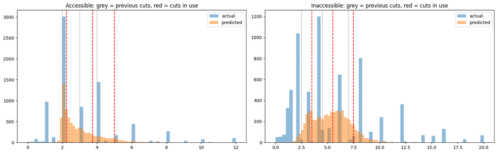

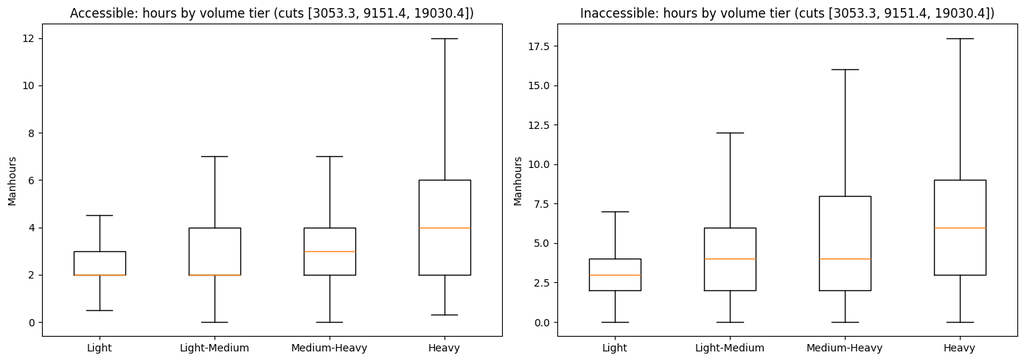

```
Hours variance explained by tiers (bid tier = what pricing actually uses)
```

|  | Scheme | Segment | Eta2_true_tier | Eta2_bid_tier |
| --- | --- | --- | --- | --- |
| 0 | hours | Accessible | 0.7593 | 0.2132 |
| 1 | hours | Inaccessible | 0.7785 | 0.1369 |
| 2 | volume | Accessible | 0.0802 | 0.0802 |
| 3 | volume | Inaccessible | 0.0549 | 0.0549 |

```
CV OOF - top-tier recall by accessibility (Regression-opt)
```

| Segment | Heavy_N | Heavy_Recall | Heavy_Precision | Predicted_One_Tier_Low_Share |
| --- | --- | --- | --- | --- |
| Accessible | 1020 | 0.2461 | 0.5133 | 0.3471 |
| Inaccessible | 1910 | 0.2052 | 0.5255 | 0.5157 |

```python
boundary_tables, RECOMMENDED_HOUR_CUTS = {}, {}
for seg, flag in vp.SEGMENTS.items():
    idx = ctx.meta_dev.index[ctx.meta_dev["inaccessible"].eq(flag).to_numpy()]
    ys, ps = ctx.y_dev.loc[idx].to_numpy(), REG_OOF.loc[idx].to_numpy()
    boundary_tables[seg] = vp.recommend_boundaries(ys, ps, len(vp.TIER_LABELS))
    RECOMMENDED_HOUR_CUTS[seg] = list(boundary_tables[seg].loc[0, "cuts"])
    cur = vp.score_boundaries(ys, ps, PROVISIONAL_HOUR_CUTS[seg])
    vp.show(boundary_tables[seg].head(10), f"{seg} - top hour-boundary sets (CV OOF)")
    print(f"  provisional {cur['cuts']}: acc={cur['tier_acc']:.3f} qwk={cur['qwk']:.3f} eta2={cur['eta2']:.3f} "
          f"shares={cur['shares']}")
HOUR_CUTS = HOUR_CUTS_OVERRIDE or (RECOMMENDED_HOUR_CUTS if USE_RECOMMENDED_HOUR_CUTS else PROVISIONAL_HOUR_CUTS)
VOLUME_CUTS = vp.volume_quartile_cuts(FULL_X["train"], FULL_META["train"], VOLUME_BIN_SCOPE)
SCHEMES = {"hours": vp.TierScheme("hours", HOUR_CUTS), "volume": vp.TierScheme("volume", VOLUME_CUTS)}
print(f"Hour cuts: {HOUR_CUTS}\nVolume cuts ({VOLUME_BIN_SCOPE}): { {k: [round(c, 1) for c in v] for k, v in VOLUME_CUTS.items()} }")

vol_share = pd.concat({s: pd.Series(SCHEMES['volume'].true_tier(FULL_X[s], FULL_Y[s], FULL_META[s]))
                       .map(dict(enumerate(vp.TIER_LABELS))).value_counts(normalize=True)
                       for s in ["train", "valid", "test", "holdout"]}, axis=1).reindex(vp.TIER_LABELS)
vp.show(vol_share, "Volume-tier share by split (cuts fit on Train)")

hour_idx = {seg: ctx.meta_dev.index[ctx.meta_dev["inaccessible"].eq(f).to_numpy()] for seg, f in vp.SEGMENTS.items()}
vp.plot_tier_boundaries({s: ctx.y_dev.loc[i].to_numpy() for s, i in hour_idx.items()},
                        {s: REG_OOF.loc[i].to_numpy() for s, i in hour_idx.items()},
                        HOUR_CUTS, PROVISIONAL_HOUR_CUTS, fig("12_hour_tier_boundaries.png"), SHOW_PLOTS)
vp.plot_volume_tiers(ctx.X_dev, ctx.y_dev, ctx.meta_dev, SCHEMES["volume"], fig("12_volume_tiers.png"), SHOW_PLOTS)

# How much of the hour variance does each scheme's TRUE tier explain (per regime)?
eta_rows = []
for name, scheme in SCHEMES.items():
    tt = scheme.true_tier(ctx.X_dev, ctx.y_dev, ctx.meta_dev)
    for seg, flag in vp.SEGMENTS.items():
        m = ctx.meta_dev["inaccessible"].eq(flag).to_numpy()
        eta_rows.append({"Scheme": name, "Segment": seg, "Eta2_true_tier": vp.class_eta2(ctx.y_dev[m], tt[m]),
                         "Eta2_bid_tier": vp.class_eta2(ctx.y_dev[m], scheme.bid_tier(ctx.X_dev, REG_OOF, ctx.meta_dev)[m])})
vp.show(pd.DataFrame(eta_rows), "Hours variance explained by tiers (bid tier = what pricing actually uses)")


CV_HEAVY_RECALL = vp.heavy_tier_recall_table(ctx.y_dev, REG_OOF, ctx.meta_dev, SCHEMES["hours"], ctx.X_dev)
vp.show(CV_HEAVY_RECALL, "CV OOF - top-tier recall by accessibility (Regression-opt)")
```

## 13. Sample-weighted tuning (replaces over/under-sampling)

Tier weights come from how badly the tuned regression models handle each tier on CV: hours → 1 − recall of the true hour tier; volume → relative MAE + relative under-prediction of the volume tier. Row weight = 1 + `weight_strength` × badness (normalized to mean 1). `weight_strength` is searched **from 0**, and the search is seeded with the unweighted regression winner, so CV can reject weighting (it hurt in an earlier iteration). Objective (lower = better, each term relative to the regression winner): hours = MAE + feeder WAPE + hour-tier loss + class WAPE; volume = MAE + feeder WAPE + class WAPE.

```python
WEIGHTINGS = {n: vp.TierWeighting.from_oof(SCHEMES[n], ctx.X_dev, ctx.y_dev, REG_OOF, ctx.meta_dev)
              for n in TIER_SCHEMES_TO_TUNE}
for n, tw in WEIGHTINGS.items():
    vp.show(pd.DataFrame(tw.badness, index=vp.TIER_LABELS), f"{n} tiers - badness (0 = fine, 1 = worst tier)")

WEIGHTED_PATH = os.path.join(OUTPUT_DIR, "unit_weighted_params.json")
expected_w = {f"{n}|{u.name}": {"features": REG_SPEC[u.name]["features"],
                                "families": REG_SPEC[u.name]["families_used"],
                                "cuts": SCHEMES[n].to_dict()["cuts"], "badness": WEIGHTINGS[n].badness}
              for n in TIER_SCHEMES_TO_TUNE for u in UNITS}
WEIGHTED_SPEC = {}
if TUNE_WEIGHTED is True or (TUNE_WEIGHTED == "auto" and not vp.spec_is_current(WEIGHTED_PATH, expected_w)):
    for n in TIER_SCHEMES_TO_TUNE:
        for u in UNITS:
            key = f"{n}|{u.name}"
            idx = reg_cv[u.name]["oof"].index
            ref_terms = vp.raw_objective_terms(ctx, idx, reg_cv[u.name]["oof"].to_numpy(), SCHEMES[n])
            objective_fn = vp.make_objective_fn(ctx, ref_terms, SCHEMES[n])
            fams = REG_SPEC[u.name]["families_used"]
            seed = {**REG_SPEC[u.name]["trial_params"], "loss_family": REG_SPEC[u.name]["best_family"],
                    "weight_strength": 0.0}
            print(f"\nWeighted tuning [{n}] {u.name} ({DEV_CFG['n_trials_weighted']} trials)")
            study = vp.run_study(f"w_{key}", vp.make_study_objective(ctx, u, REG_SPEC[u.name]["features"], fams,
                                                                     objective_fn, WEIGHTINGS[n]),
                                 DEV_CFG["n_trials_weighted"], seed, show_progress=DEV_CFG["show_progress"])
            WEIGHTED_SPEC[key] = {**expected_w[key], "trial_params": study.best_trial.params,
                                  "cv_objective": study.best_value}
    vp.write_json(WEIGHTED_SPEC, WEIGHTED_PATH)
else:
    WEIGHTED_SPEC = vp.read_json(WEIGHTED_PATH)
    print(f"Loaded weighted specs from {WEIGHTED_PATH}")

weighted_cv, WEIGHTED_OOF, w_rows = {}, {}, []
for n in TIER_SCHEMES_TO_TUNE:
    tw = WEIGHTINGS[n]
    preds = {}
    for u in UNITS:
        key = f"{n}|{u.name}"
        s = WEIGHTED_SPEC[key]
        s["params"] = vp.params_from_trial(s["trial_params"], s["families"], DEV_CFG["max_iterations"])
        s["strength"] = float(s["trial_params"].get("weight_strength", 0.0))
        wfn = None if s["strength"] == 0 else (
            lambda idx, st=s["strength"]: tw.row_weights(ctx.X_dev.loc[idx], ctx.y_dev.loc[idx], ctx.meta_dev.loc[idx], st))
        r = vp.cv_unit(ctx, u, s["features"], s["params"], weight_fn=wfn)
        s["cv_best_iteration"] = r["best_iteration"]
        weighted_cv[key], preds[u.name] = r, r["oof"]
        w_rows.append({"Scheme": n, "Unit": u.name, "loss": s["params"]["loss_function"],
                       "weight_strength": s["strength"], "cv_mae": r["mae"],
                       "reg_cv_mae": reg_cv[u.name]["mae"], "sum_ratio": r["sum_ratio"]})
    WEIGHTED_OOF[n] = vp.combine_predictions(preds, ctx.X_dev.index)
vp.show(pd.DataFrame(w_rows), "Weighted models (CV) - weight_strength 0 means CV rejected weighting")
for n in TIER_SCHEMES_TO_TUNE:
    for u in UNITS:
        st = WEIGHTED_SPEC[f"{n}|{u.name}"]["strength"]
        if st > 0:
            vp.show(WEIGHTINGS[n].weight_table(st), f"[{n}] {u.name} effective tier weights (before mean-normalizing)", 3)
```

```
hours tiers - badness (0 = fine, 1 = worst tier)
```

|  | Accessible | Inaccessible |
| --- | --- | --- |
| Light | 0.6778 | 0.8447 |
| Light-Medium | 0.5663 | 0.7346 |
| Medium-Heavy | 1.0000 | 0.7430 |
| Heavy | 0.9883 | 1.0000 |

```
volume tiers - badness (0 = fine, 1 = worst tier)
```

|  | Accessible | Inaccessible |
| --- | --- | --- |
| Light | 0.8562 | 0.9429 |
| Light-Medium | 0.8704 | 0.9498 |
| Medium-Heavy | 0.9180 | 0.9516 |
| Heavy | 1.0000 | 1.0000 |

```
Weighted tuning [hours] Accessible (25 trials)
```

```
Weighted tuning [hours] Inaccessible-Suburban (25 trials)
```

```
Weighted tuning [hours] Inaccessible-Rural (25 trials)
```

```
Weighted tuning [hours] Inaccessible-Urban (25 trials)
```

```
Weighted tuning [volume] Accessible (25 trials)
```

```
Weighted tuning [volume] Inaccessible-Suburban (25 trials)
```

```
Weighted tuning [volume] Inaccessible-Rural (25 trials)
```

```
Weighted tuning [volume] Inaccessible-Urban (25 trials)
```

```
Weighted models (CV) - weight_strength 0 means CV rejected weighting
```

|  | Scheme | Unit | loss | weight_strength | cv_mae | reg_cv_mae | sum_ratio |
| --- | --- | --- | --- | --- | --- | --- | --- |
| 0 | hours | Accessible | Tweedie:variance_power=1.896 | 0.9498 | 1.3247 | 1.2837 | 0.9753 |
| 1 | hours | Inaccessible-Suburban | Tweedie:variance_power=1.632 | 0.0000 | 2.9130 | 2.9130 | 0.9772 |
| 2 | hours | Inaccessible-Rural | Quantile:alpha=0.65 | 1.8269 | 3.2860 | 3.3217 | 1.1118 |
| 3 | hours | Inaccessible-Urban | Tweedie:variance_power=1.102 | 0.8890 | 2.1680 | 2.1542 | 0.9990 |
| 4 | volume | Accessible | Tweedie:variance_power=1.574 | 1.9895 | 1.3163 | 1.2837 | 0.9814 |
| 5 | volume | Inaccessible-Suburban | Tweedie:variance_power=1.632 | 0.0000 | 2.9130 | 2.9130 | 0.9772 |
| 6 | volume | Inaccessible-Rural | Quantile:alpha=0.65 | 2.6557 | 3.2844 | 3.3217 | 1.0863 |
| 7 | volume | Inaccessible-Urban | Tweedie:variance_power=1.109 | 1.1002 | 2.1641 | 2.1542 | 0.9875 |

```
[hours] Accessible effective tier weights (before mean-normalizing)
```

|  | Accessible | Inaccessible |
| --- | --- | --- |
| Light | 1.644 | 1.802 |
| Light-Medium | 1.538 | 1.698 |
| Medium-Heavy | 1.950 | 1.706 |
| Heavy | 1.939 | 1.950 |

```
[hours] Inaccessible-Rural effective tier weights (before mean-normalizing)
```

|  | Accessible | Inaccessible |
| --- | --- | --- |
| Light | 2.238 | 2.543 |
| Light-Medium | 2.035 | 2.342 |
| Medium-Heavy | 2.827 | 2.357 |
| Heavy | 2.806 | 2.827 |

```
[hours] Inaccessible-Urban effective tier weights (before mean-normalizing)
```

|  | Accessible | Inaccessible |
| --- | --- | --- |
| Light | 1.603 | 1.751 |
| Light-Medium | 1.503 | 1.653 |
| Medium-Heavy | 1.889 | 1.661 |
| Heavy | 1.879 | 1.889 |

```
[volume] Accessible effective tier weights (before mean-normalizing)
```

|  | Accessible | Inaccessible |
| --- | --- | --- |
| Light | 2.703 | 2.876 |
| Light-Medium | 2.732 | 2.890 |
| Medium-Heavy | 2.826 | 2.893 |
| Heavy | 2.989 | 2.989 |

```
[volume] Inaccessible-Rural effective tier weights (before mean-normalizing)
```

|  | Accessible | Inaccessible |
| --- | --- | --- |
| Light | 3.274 | 3.504 |
| Light-Medium | 3.312 | 3.522 |
| Medium-Heavy | 3.438 | 3.527 |
| Heavy | 3.656 | 3.656 |

```
[volume] Inaccessible-Urban effective tier weights (before mean-normalizing)
```

|  | Accessible | Inaccessible |
| --- | --- | --- |
| Light | 1.942 | 2.037 |
| Light-Medium | 1.958 | 2.045 |
| Medium-Heavy | 2.010 | 2.047 |
| Heavy | 2.100 | 2.100 |

## 14. Multi-quantile models (P10 / P50 / P90)

One per unit, using the unit's tuned tree parameters. Supplies the P10/P50/P90 and prediction width of the risk tables. Span quantiles do **not** add up to feeder quantiles.

```python
MQ_ALPHAS = list(DEV_CFG["multi_quantile_alphas"])
mq_cv = {}
for u in UNITS:
    s = REG_SPEC[u.name]
    s["mq_params"] = {**s["params"], "loss_function": vp.multi_quantile_loss(MQ_ALPHAS)}
    mq_cv[u.name] = vp.cv_unit(ctx, u, s["features"], s["mq_params"], quantile_alphas=MQ_ALPHAS)
    s["mq_cv_best_iteration"] = mq_cv[u.name]["best_iteration"]
MQ_OOF = pd.concat([mq_cv[n]["oof_quantiles"] for n in UNIT_NAMES]).reindex(ctx.X_dev.index)
vp.show(vp.quantile_calibration(ctx.y_dev, MQ_OOF, ctx.meta_dev, UNITS, AREA_CLASS_COL),
        "CV quantile calibration (Cov(y<=q) should be close to the alpha; interval target 0.80)")
```

```
CV quantile calibration (Cov(y<=q) should be close to the alpha; interval target 0.80)
```

| Unit | N | Cov(y<=q10) | Pinball_q10 | Cov(y<=q50) | Pinball_q50 | Cov(y<=q90) | Pinball_q90 | Interval_Coverage | Mean_Width |
| --- | --- | --- | --- | --- | --- | --- | --- | --- | --- |
| Accessible | 7837 | 0.1304 | 0.2113 | 0.5100 | 0.6240 | 0.8949 | 0.4399 | 0.7645 | 3.9673 |
| Inaccessible-Suburban | 5674 | 0.1239 | 0.4458 | 0.5023 | 1.4334 | 0.8953 | 0.8117 | 0.7714 | 8.7806 |
| Inaccessible-Rural | 460 | 0.1522 | 0.4824 | 0.5348 | 1.5920 | 0.8696 | 1.1105 | 0.7174 | 9.0002 |
| Inaccessible-Urban | 548 | 0.1314 | 0.3351 | 0.5201 | 1.0624 | 0.9033 | 0.5840 | 0.7719 | 6.6256 |